# Absenteeism From Work

Rihad Variawa

13/5/2019

Human capital plays a crucial role in any product or service based organization. Being absent for work has consequences.

### Problem Statements

1. What changes company should bring to reduce the number of absenteeism?
2. How much losses every month can we project if same trend of absenteeism continues?

### Loading The Data

```r
# Reading the data
df = read.xlsx('Absenteeism_at_work.xls', sheetIndex = 1)
```

### The Data

There are 21 variables in our data in which 20 are independent variables and 1 (Absenteeism time in hours) is dependent variable. Since our target variable is continuous in nature, this is a regression problem.

### Variables Information:

1. Individual identification (ID)
2. Reason for absence (ICD) - Absences attested by the International Code of Diseases (ICD) stratified into 21 categories as follows:
   - Certain infectious and parasitic diseases
   - Neoplasms
   - Diseases of the blood and blood-forming organs and certain disorders involving the immune mechanism
   - Endocrine, nutritional and metabolic diseases
   - Mental and behavioral disorders
   - Diseases of the nervous system
   - Diseases of the eye and adnexa
   - Diseases of the ear and mastoid process
   - Diseases of the circulatory system
   - Diseases of the respiratory system
   - Diseases of the digestive system
   - Diseases of the skin and subcutaneous tissue
   - Diseases of the musculoskeletal system and connective tissue
   - Diseases of the genitourinary system
   - Pregnancy, childbirth and the puerperium
   - Certain conditions originating in the perinatal period
   - Congenital malformations, deformations and chromosomal abnormalities
   - Symptoms, signs and abnormal clinical and laboratory findings, not elsewhere classified
   - Injury, poisoning and certain other consequences of external causes
   - External causes of morbidity and mortality
   - Factors influencing health status and contact with health services and, 7 categories without (CID): patient follow-up (22), medical consultation (23), blood donation (24), laboratory examination (25), unjustified absence (26), physiotherapy (27), dental consultation (28).
3. Month of absence
4. Day of the week (Monday (2), Tuesday (3), Wednesday (4), Thursday (5), Friday (6))
5. Seasons (summer (1), autumn (2), winter (3), spring (4))
6. Transportation expense
7. Distance from Residence to Work (kilometers)
8. Service time
9. Age
10. Work load Average/day
11. Hit target
12. Disciplinary failure (yes=1; no=0)
13. Education (high school (1), graduate (2), postgraduate (3), master and doctor (4))
14. Son (number of children)
15. Social drinker (yes=1; no=0)
16. Social smoker (yes=1; no=0)
17. Pet (number of pet)
18. Weight
19. Height
20. Body mass index
21. Absenteeism time in hours (target)

### Exploratory Data Analysis

```r
# Shape of the data
dim(df)
```

```
[1] 740  21
```

```r
# Viewing data
#View(df)
```

```r
# Structure of the data
str(df)
```

```
'data.frame':   740 obs. of  21 variables:
 $ ID                             : num  11 36 3 7 11 3 10 20 14 1 ...
 $ Reason.for.absence             : num  26 0 23 7 23 23 22 23 19 22 ...
 $ Month.of.absence               : num  7 7 7 7 7 7 7 7 7 7 ...
 $ Day.of.the.week                : num  3 3 4 5 5 6 6 6 2 2 ...
 $ Seasons                        : num  1 1 1 1 1 1 1 1 1 1 ...
 $ Transportation.expense         : num  289 118 179 279 289 179 NA 260 155 235 ...
 $ Distance.from.Residence.to.Work: num  36 13 51 5 36 51 52 50 12 11 ...
 $ Service.time                   : num  13 18 18 14 13 18 3 11 14 14 ...
 $ Age                            : num  33 50 38 39 33 38 28 36 34 37 ...
 $ Work.load.Average.day.         : num  239554 239554 239554 239554 239554 ...
 $ Hit.target                     : num  97 97 97 97 97 97 97 97 97 97 ...
 $ Disciplinary.failure           : num  0 1 0 0 0 0 0 0 0 0 ...
 $ Education                      : num  1 1 1 1 1 1 1 1 1 3 ...
 $ Son                            : num  2 1 0 2 2 0 1 4 2 1 ...
 $ Social.drinker                 : num  1 1 1 1 1 1 1 1 1 0 ...
 $ Social.smoker                  : num  0 0 0 1 0 0 0 0 0 0 ...
 $ Pet                            : num  1 0 0 0 1 0 4 0 0 1 ...
 $ Weight                         : num  90 98 89 68 90 89 80 65 95 88 ...
 $ Height                         : num  172 178 170 168 172 170 172 168 196 172 ...
 $ Body.mass.index                : num  30 31 31 24 30 31 27 23 25 29 ...
 $ Absenteeism.time.in.hours      : num  4 0 2 4 2 NA 8 4 40 8 ...
```

From EDA we conclude that there are 10 continuous variable and 11 categorical variable in nature.

```r
# Variable names of the data
colnames(df)
```

```
 [1] "ID"                              "Reason.for.absence"
 [3] "Month.of.absence"                "Day.of.the.week"
 [5] "Seasons"                         "Transportation.expense"
 [7] "Distance.from.Residence.to.Work" "Service.time"
 [9] "Age"                             "Work.load.Average.day."
[11] "Hit.target"                      "Disciplinary.failure"
[13] "Education"                       "Son"
[15] "Social.drinker"                  "Social.smoker"
[17] "Pet"                             "Weight"
[19] "Height"                          "Body.mass.index"
[21] "Absenteeism.time.in.hours"
```

```r
# From the above EDA and problem statement categorising data in 2 category "continuous" and "catagorical"
continuous_vars = c('Distance.from.Residence.to.Work', 'Service.time', 'Age',
            'Work.load.Average.day.', 'Transportation.expense',
            'Hit.target', 'Weight', 'Height',
            'Body.mass.index', 'Absenteeism.time.in.hours')

catagorical_vars = c('ID','Reason.for.absence','Month.of.absence','Day.of.the.week',
                     'Seasons','Disciplinary.failure', 'Education', 'Social.drinker',
                     'Social.smoker', 'Son', 'Pet')
```

### Missing Data

In statistics, missing data, or missing values, occur when no data value is stored for the variable in an observation. Missing data are a common occurrence and can have a significant effect on the conclusions that can be drawn from the data. If a columns has more than 30% of data as missing value either we ignore the entire column or we ignore those observations.

In the given data the maximum percentage of missing value is 4.189% for body mass index column. So we’ll compute missing value for all the columns.

```r
# Creating dataframe with missing values present in each variable
missing_val = data.frame(apply(df,2,function(x){sum(is.na(x))}))
missing_val$Columns = row.names(missing_val)
names(missing_val)[1] =  "Missing_percentage"
```

```r
# Calculate percentage of missing value
missing_val$Missing_percentage = (missing_val$Missing_percentage/nrow(df)) * 100

print(missing_val$Missing_percentage)
```

```
 [1] 0.0000000 0.4054054 0.1351351 0.0000000 0.0000000 0.9459459 0.4054054
 [8] 0.4054054 0.4054054 1.3513514 0.8108108 0.8108108 1.3513514 0.8108108
[15] 0.4054054 0.5405405 0.2702703 0.1351351 1.8918919 4.1891892 2.9729730
```

```r
# Sorting missing_val in Descending order
missing_val = missing_val[order(-missing_val$Missing_percentage),]
row.names(missing_val) = NULL

print(missing_val)
```

```
   Missing_percentage                         Columns
1           4.1891892                 Body.mass.index
2           2.9729730       Absenteeism.time.in.hours
3           1.8918919                          Height
4           1.3513514          Work.load.Average.day.
5           1.3513514                       Education
6           0.9459459          Transportation.expense
7           0.8108108                      Hit.target
8           0.8108108            Disciplinary.failure
9           0.8108108                             Son
10          0.5405405                   Social.smoker
11          0.4054054              Reason.for.absence
12          0.4054054 Distance.from.Residence.to.Work
13          0.4054054                    Service.time
14          0.4054054                             Age
15          0.4054054                  Social.drinker
16          0.2702703                             Pet
17          0.1351351                Month.of.absence
18          0.1351351                          Weight
19          0.0000000                              ID
20          0.0000000                 Day.of.the.week
21          0.0000000                         Seasons
```

```r
# Reordering columns
missing_val = missing_val[,c(2,1)]
```

```r
# Saving output result into csv file
write.csv(missing_val, "Missing_perc_R.csv", row.names = F)
```

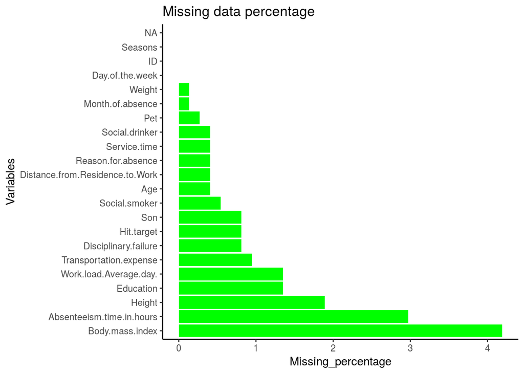

```r
# Plot
ggplot(data = missing_val[1:28,], aes(x=reorder(Columns, -Missing_percentage),y = Missing_percentage))+
geom_bar(stat = "identity", fill = "green") + xlab("Variables")+
ggtitle("Missing data percentage") + theme_bw() + theme_classic() + coord_flip()
```

```r
# Actual Value = 23
# Mean = 26.68
# Median = 25
# KNN = 23

# Mean Method
df$Body.mass.index[is.na(df$Body.mass.index)] = mean(df$Body.mass.index, na.rm = T)

# Median Method
df$Body.mass.index[is.na(df$Body.mass.index)] = median(df$Body.mass.index, na.rm = T)

# kNN Imputation
df = knnImputation(df, k = 3)

# Checking for missing value
sum(is.na(df))
```

```
[1] 0
```

### Outliers

In this case we use a classic approach of removing outliers. We visualize the outliers using boxplots.

#### BoxPlots - Distribution and Outlier Check

```r
# Boxplot for continuous variables
for (i in 1:length(continuous_vars))
{
  assign(paste0("gn",i), ggplot(aes_string(y = (continuous_vars[i]), x = "Absenteeism.time.in.hours"), data = subset(df)) +
           stat_boxplot(geom = "errorbar", width = 0.5) + theme_classic() +
           geom_boxplot(outlier.colour="red", fill = "green" ,outlier.shape=18,
                        outlier.size=1, notch=FALSE) +
           theme(legend.position="bottom")+
           labs(y=continuous_vars[i],x="Absenteeism.time.in.hours")+
           ggtitle(paste("Box plot of absenteeism for",continuous_vars[i])))
}
```

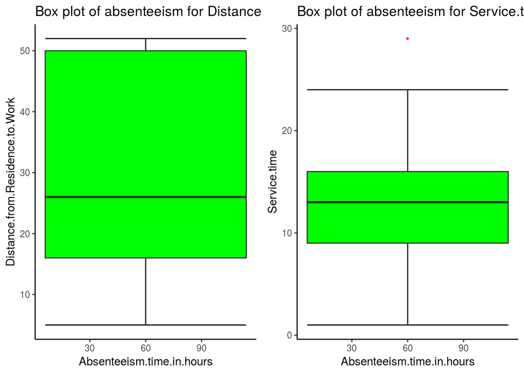

```r
# Plotting plots together
gridExtra::grid.arrange(gn1,gn2,ncol=2)
```

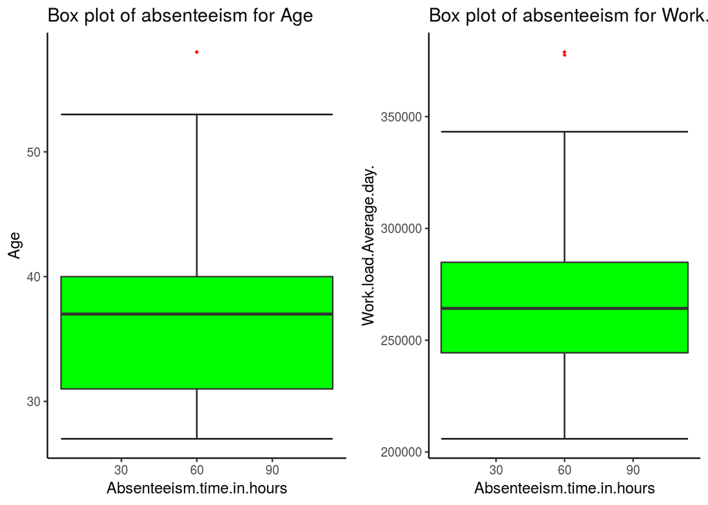

```r
gridExtra::grid.arrange(gn3,gn4,ncol=2)
```

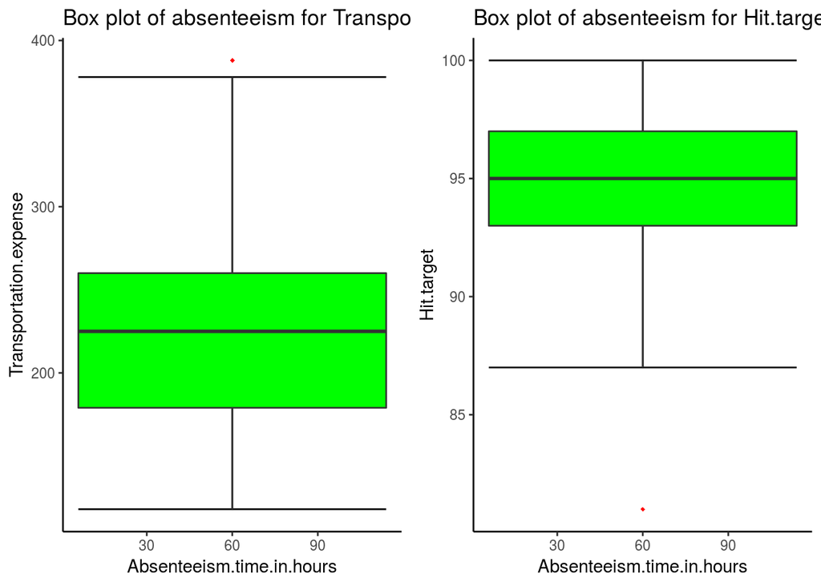

```r
gridExtra::grid.arrange(gn5,gn6,ncol=2)
```

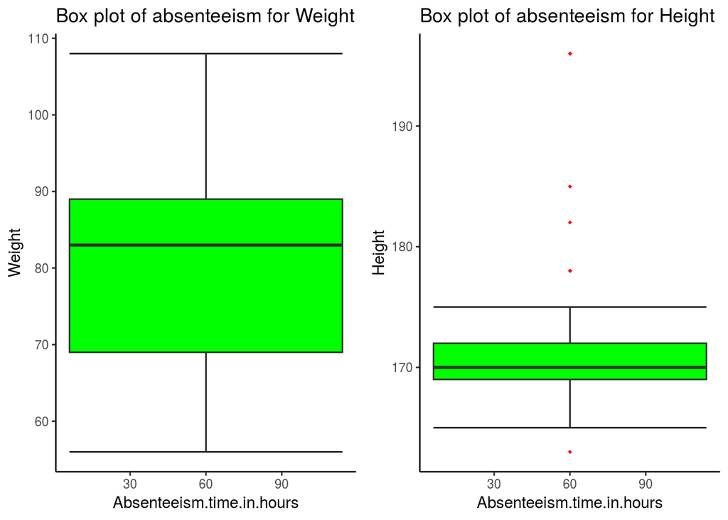

```r
gridExtra::grid.arrange(gn7,gn8,ncol=2)
```

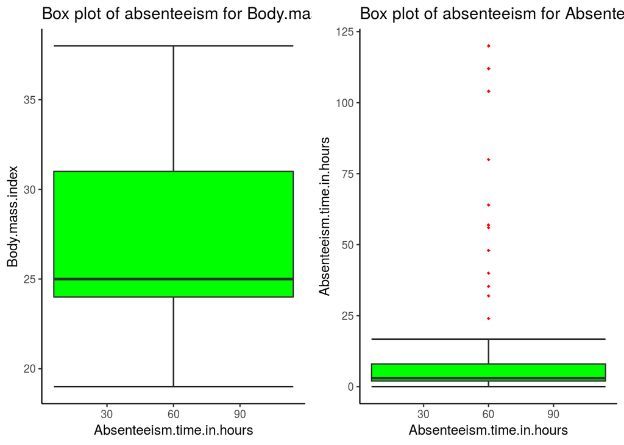

```r
gridExtra::grid.arrange(gn9,gn10,ncol=2)
```

From the boxplot, almost all the variables except “Distance from residence to work”, “Weight” and “Body mass index” consists of outliers. We have converted the outliers (data beyond minimum and maximum values) as NA i.e. missing values and fill them by KNN imputation method.

#### Remove outliers using boxplot method

```r
# Loop to remove from all variables
for(i in continuous_vars)
{
  print(i)
  val = df[,i][df[,i] %in% boxplot.stats(df[,i])$out]
  # print(length(val))
  df = df[which(!df[,i] %in% val),]
}
```

```
[1] "Distance.from.Residence.to.Work"
[1] "Service.time"
[1] "Age"
[1] "Work.load.Average.day."
[1] "Transportation.expense"
[1] "Hit.target"
[1] "Weight"
[1] "Height"
[1] "Body.mass.index"
[1] "Absenteeism.time.in.hours"
```

```r
# Replace all outliers with NA and impute
for(i in continuous_vars)
{
  val = df[,i][df[,i] %in% boxplot.stats(df[,i])$out]
  # print(length(val))
  df[,i][df[,i] %in% val] = NA
}
```

```r
# Imputing missing values
df = knnImputation(df,k=3)
```

### Feature Selection

Prior to performing any type of modeling we need to assess the importance of each predictor variable in our analysis. There is a possibility that many variables in our analysis are not important at all to the problem of class prediction. Selecting subset of relevant columns for the model construction is known as **feature selection.**

We cannot use all the features because some features may be carrying the same information or irrelevant information which can increase overheads. To reduce overheads we adopt feature selection technique to extract meaningful features out of data. This in turn helps us to avoid the problem of multi collinearity.

For this project I’ve selected Correlation Analysis for numerical variable and ANOVA (Analysis of variance) for categorical variable.

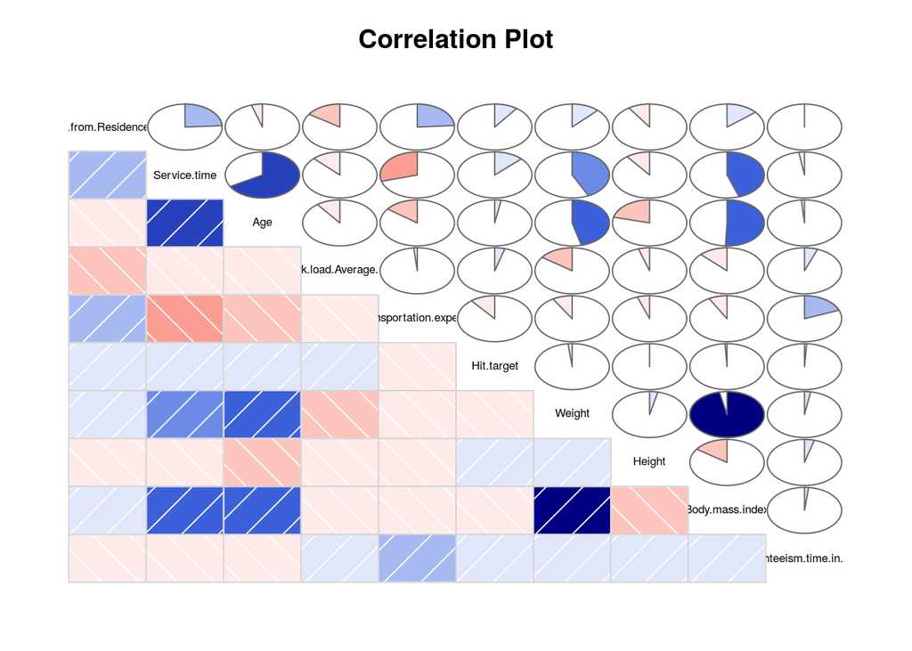

```r
# Correlation plot
corrgram(df[,continuous_vars], order = F,
         upper.panel=panel.pie, text.panel=panel.txt, main = "Correlation Plot")
```

```r
# ANOVA test for categprical variable
summary(aov(formula = Absenteeism.time.in.hours~ID,data = df))
```

```
             Df Sum Sq Mean Sq F value  Pr(>F)
ID            1     92   92.47   8.573 0.00355 **
Residuals   542   5846   10.79
---
Signif. codes:  0 '***' 0.001 '**' 0.01 '*' 0.05 '.' 0.1 ' ' 1
```

```r
summary(aov(formula = Absenteeism.time.in.hours~Reason.for.absence,data = df))
```

```
                    Df Sum Sq Mean Sq F value   Pr(>F)
Reason.for.absence   1    133  132.86    12.4 0.000464 ***
Residuals          542   5805   10.71
---
Signif. codes:  0 '***' 0.001 '**' 0.01 '*' 0.05 '.' 0.1 ' ' 1
```

```r
summary(aov(formula = Absenteeism.time.in.hours~Month.of.absence,data = df))
```

```
                  Df Sum Sq Mean Sq F value Pr(>F)
Month.of.absence   1      3    3.04   0.278  0.599
Residuals        542   5935   10.95
```

```r
summary(aov(formula = Absenteeism.time.in.hours~Day.of.the.week,data = df))
```

```
                 Df Sum Sq Mean Sq F value Pr(>F)
Day.of.the.week   1     40   39.75   3.653 0.0565 .
Residuals       542   5898   10.88
---
Signif. codes:  0 '***' 0.001 '**' 0.01 '*' 0.05 '.' 0.1 ' ' 1
```

```r
summary(aov(formula = Absenteeism.time.in.hours~Seasons,data = df))
```

```
             Df Sum Sq Mean Sq F value Pr(>F)
Seasons       1      4   4.121   0.376   0.54
Residuals   542   5934  10.949
```

```r
summary(aov(formula = Absenteeism.time.in.hours~Disciplinary.failure,data = df))
```

```
                      Df Sum Sq Mean Sq F value   Pr(>F)
Disciplinary.failure   1    344   343.8   33.31 1.32e-08 ***
Residuals            542   5594    10.3
---
Signif. codes:  0 '***' 0.001 '**' 0.01 '*' 0.05 '.' 0.1 ' ' 1
```

```r
summary(aov(formula = Absenteeism.time.in.hours~Education,data = df))
```

```
             Df Sum Sq Mean Sq F value Pr(>F)
Education     1      1   0.953   0.087  0.768
Residuals   542   5937  10.954
```

```r
summary(aov(formula = Absenteeism.time.in.hours~Social.drinker,data = df))
```

```
                Df Sum Sq Mean Sq F value  Pr(>F)
Social.drinker   1    106  106.28   9.877 0.00176 **
Residuals      542   5832   10.76
---
Signif. codes:  0 '***' 0.001 '**' 0.01 '*' 0.05 '.' 0.1 ' ' 1
```

```r
summary(aov(formula = Absenteeism.time.in.hours~Social.smoker,data = df))
```

```
               Df Sum Sq Mean Sq F value Pr(>F)
Social.smoker   1     34   34.23   3.142 0.0768 .
Residuals     542   5904   10.89
---
Signif. codes:  0 '***' 0.001 '**' 0.01 '*' 0.05 '.' 0.1 ' ' 1
```

```r
summary(aov(formula = Absenteeism.time.in.hours~Son,data = df))
```

```
             Df Sum Sq Mean Sq F value   Pr(>F)
Son           1    242  242.18   23.04 2.05e-06 ***
Residuals   542   5696   10.51
---
Signif. codes:  0 '***' 0.001 '**' 0.01 '*' 0.05 '.' 0.1 ' ' 1
```

```r
summary(aov(formula = Absenteeism.time.in.hours~Pet,data = df))
```

```
             Df Sum Sq Mean Sq F value Pr(>F)
Pet           1      5   5.421   0.495  0.482
Residuals   542   5933  10.946
```

```r
# Dimension reduction
df = subset(df, select = -c(Weight))
```

### Feature Scaling

A method used to standardize the range of independent variables or features of data. In data processing, it’s also known as data normalization and is generally performed during the data pre-processing step. Since the range of values of raw data varies widely, in some machine learning algorithms, objective functions will not work properly without normalization.

For example, the majority of classifiers compute the distance between two points by the Euclidean distance. If one of the features has a broad range of values, the distance will be governed by this particular feature. Therefore, the range of all features should be normalized so that each feature contributes approximately proportionately to the final distance. Since our data is not uniformly distributed we’ll use Normalization as Feature Scaling Method.

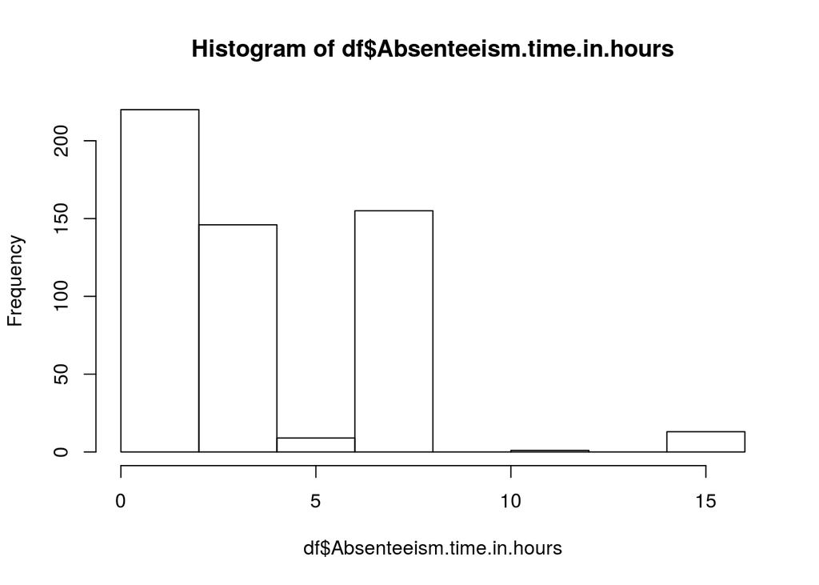

```r
# Normality check
hist(df$Absenteeism.time.in.hours)
```

```r
# Updating the continuous and catagorical variable
continuous_vars = c('Distance.from.Residence.to.Work', 'Service.time', 'Age',
                    'Work.load.Average.day.', 'Transportation.expense',
                    'Hit.target', 'Height',
                    'Body.mass.index')
```

```r
catagorical_vars = c('ID','Reason.for.absence','Disciplinary.failure',
                     'Social.drinker', 'Son', 'Pet', 'Month.of.absence', 'Day.of.the.week', 'Seasons',
                     'Education', 'Social.smoker')
```

```r
# Normalization
for(i in continuous_vars)
{
  print(i)
  df[,i] = (df[,i] - min(df[,i]))/(max(df[,i])-min(df[,i]))
}
```

```
[1] "Distance.from.Residence.to.Work"
[1] "Service.time"
[1] "Age"
[1] "Work.load.Average.day."
[1] "Transportation.expense"
[1] "Hit.target"
[1] "Height"
[1] "Body.mass.index"
```

```r
# Creating dummy variables for categorical variables
library(mlr)
df = dummy.data.frame(df, catagorical_vars)
```

[output not shown]